# Bayesian ensemble of model v0.4.2 (configuration v0.4.2; real, 100 members)

Created 2026-11-26 11:47:17. Product 0.4.2+ens.100. Median std on rock nodes: Vp 0.175 km/s, Vs 0.109 km/s; resolved nodes P/S [888, 320]; sampled nodes P/S [3753, 808] (raw member spreads; calibrated: x the factors below).

## Uncertainty calibration (D-B099)

**Vp and Vs spreads multiplied by 1.50 (Vp) and 1.35 (Vs)**, applied to Vp (x 1.50), Vp_tomography (x 1.50), Vs (x 1.35), Vs_tomography (x 1.35); the raw member statistics are in the variables *_raw. Not inflated: mean, median, n, VpVs, hypocentres (not in this product).

Rule: D-B094: spreads multiplied by f about the ensemble median (std -> f std; p05 / p95 -> median + f (p - median)); f = max(f68, f95) on the resolved nodes of the synthetic calibration, rounded up to the next 0.05, f68 / f95 = the smallest factor bringing the 16-84 % / 2.5-97.5 % coverage of the truth to 0.68 / 0.95 (b2_ens_inflate.py); hypocentres and Vp/Vs not inflated; raw member statistics kept as <name>_raw.

Source: synthetic calibration /wd1/mdenolle_data/tomo_v1/ensemble_v0.4.2/synth/coverage.json (md5 c032bcb392aa6b6995e46b418aca70e8, result FAIL; accepted md5 c032bcb392aa6b6995e46b418aca70e8).

Derivation: /wd1/mdenolle_data/tomo_v1/ensemble_v0.4.2/calibration/inflation.json (md5 1ed0ad4a7dfbc9e9ee2a597a233d6434), factors {"Vp": 1.5, "Vs": 1.35}.

| resolved nodes | nodes | 68 % raw | 95 % raw | f68 | f95 | factor (rounded up) | 68 % after | 95 % after |
| --- | --- | --- | --- | --- | --- | --- | --- | --- |
| Vp | 888 | 0.5428 | 0.8401 | 1.360 | 1.480 | 1.50 | 0.7252 | 0.9527 |
| Vs | 320 | 0.5437 | 0.8406 | 1.343 | 1.313 | 1.35 | 0.6813 | 0.9531 |

**All items (sampled nodes, per tile, Gaussian)**

```
# D-B094 inflation factors of the Vp and Vs spreads (configuration v0.4.2)

Source: /wd1/mdenolle_data/tomo_v1/ensemble_v0.4.2/synth/coverage.json (md5 c032bcb392aa6b6995e46b418aca70e8; configuration v0.4.2, truth v0.4.2, 100 synthetic members, result FAIL). Created 2026-11-26 15:47:22.

Rule: x' = median + f (x - median) per node (percentile intervals about the median and std x f); f = max(f68, f95) on the resolved nodes, rounded up to the next 0.05; f68 / f95 = smallest f with 16-84 % / 2.5-97.5 % coverage of the truth >= 0.68 / 0.95; hypocentres and Vp/Vs not inflated.

**Factors used: Vp 1.50, Vs 1.35** (resolved nodes).

| item | nodes | 68 % raw | 95 % raw | f68 | f95 | max | rounded up | 68 % after (used f) | 95 % after (used f) | rms z raw / after | Gauss 68 / 95 raw | Gauss 68 / 95 after |
|---|---|---|---|---|---|---|---|---|---|---|---|---|
| resolved_Vp | 888 | 0.5428 | 0.8401 | 1.360 | 1.480 | 1.480 | 1.50 | 0.7252 | 0.9527 | 1.33 / 0.887 | 0.5574 / 0.8592 | 0.7421 / 0.9662 |
| resolved_Vp_mendocino_gorda_c | 83 | 0.6024 | 0.9157 | 1.207 | 1.139 | 1.207 | 1.25 | 0.7831 | 0.988 | 1.087 / 0.725 | 0.6145 / 0.9277 | 0.8313 / 1.0 |
| resolved_Vp_blanco | 346 | 0.5347 | 0.8208 | 1.364 | 1.536 | 1.536 | 1.55 | 0.7168 | 0.9364 | 1.37 / 0.913 | 0.552 / 0.841 | 0.7283 / 0.9624 |
| resolved_Vp_oregon | 29 | 0.4138 | 0.6897 | 2.055 | 1.873 | 2.055 | 2.10 | 0.4828 | 0.8966 | 1.823 / 1.215 | 0.3793 / 0.6552 | 0.5517 / 0.8966 |
| resolved_Vp_washington | 430 | 0.5465 | 0.8512 | 1.297 | 1.355 | 1.355 | 1.40 | 0.7372 | 0.9628 | 1.299 / 0.866 | 0.5628 / 0.8744 | 0.7488 / 0.9674 |
| resolved_Vs | 320 | 0.5437 | 0.8406 | 1.343 | 1.313 | 1.343 | 1.35 | 0.6813 | 0.9531 | 1.294 / 0.959 | 0.5469 / 0.8625 | 0.6781 / 0.9625 |
| resolved_Vs_mendocino_gorda_c | 0 | | | | | | | | | | | |
| resolved_Vs_blanco | 320 | 0.5437 | 0.8406 | 1.343 | 1.313 | 1.343 | 1.35 | 0.6813 | 0.9531 | 1.294 / 0.959 | 0.5469 / 0.8625 | 0.6781 / 0.9625 |
| resolved_Vs_oregon | 0 | | | | | | | | | | | |
| resolved_Vs_washington | 0 | | | | | | | | | | | |
| sampled_Vp | 3588 | 0.5641 | 0.8453 | 1.290 | 1.456 | 1.456 | 1.50 | 0.7386 | 0.9562 | 1.335 / 0.89 | 0.5856 / 0.8662 | 0.7542 / 0.9671 |
| sampled_Vp_mendocino_gorda_c | 1081 | 0.5245 | 0.8159 | 1.440 | 1.529 | 1.529 | 1.55 | 0.6994 | 0.9454 | 1.504 / 1.003 | 0.5467 / 0.8326 | 0.7095 / 0.9584 |
| sampled_Vp_blanco | 311 | 0.5016 | 0.7974 | 1.490 | 1.698 | 1.698 | 1.70 | 0.6849 | 0.9325 | 1.444 / 0.963 | 0.5113 / 0.8232 | 0.6881 / 0.9582 |
| sampled_Vp_oregon | 492 | 0.628 | 0.8902 | 1.133 | 1.222 | 1.222 | 1.25 | 0.7947 | 0.9776 | 1.16 / 0.773 | 0.6463 / 0.8963 | 0.811 / 0.9797 |
| sampled_Vp_washington | 1704 | 0.5822 | 0.8597 | 1.246 | 1.409 | 1.409 | 1.45 | 0.757 | 0.9613 | 1.245 / 0.83 | 0.6062 / 0.8867 | 0.7782 / 0.9707 |
| sampled_Vs | 752 | 0.5997 | 0.883 | 1.215 | 1.243 | 1.243 | 1.25 | 0.7247 | 0.9628 | 1.184 / 0.877 | 0.621 / 0.9043 | 0.738 / 0.9721 |
| sampled_Vs_mendocino_gorda_c | 266 | 0.594 | 0.891 | 1.215 | 1.188 | 1.215 | 1.25 | 0.7368 | 0.9737 | 1.143 / 0.847 | 0.6203 / 0.906 | 0.7519 / 0.9774 |
| sampled_Vs_blanco | 70 | 0.5286 | 0.8714 | 1.343 | 1.374 | 1.374 | 1.40 | 0.6857 | 0.9286 | 1.287 / 0.953 | 0.5286 / 0.8714 | 0.6857 / 0.9714 |
| sampled_Vs_oregon | 81 | 0.6914 | 0.9012 | 0.995 | 1.369 | 1.369 | 1.40 | 0.7901 | 0.9383 | 1.189 / 0.881 | 0.6914 / 0.9012 | 0.7778 / 0.9506 |
| sampled_Vs_washington | 335 | 0.597 | 0.8746 | 1.268 | 1.249 | 1.268 | 1.30 | 0.7075 | 0.9672 | 1.192 / 0.883 | 0.6239 / 0.9104 | 0.7284 / 0.9731 |
```

## Run cost per member

| stage | median wall (min) | max wall (min) | max RSS (GB) | kept (MB, mean) |
| --- | --- | --- | --- | --- |
| m0 | 20.3 | 20.9 | 2.54 | 15 |
| mendocino_gorda_c | 32.4 | 35.3 | 3.29 | 10 |
| blanco | 13.2 | 16.2 | 1.79 | 7 |
| oregon | 13.3 | 16.5 | 2.02 | 10 |
| washington | 42.5 | 45.7 | 3.72 | 12 |

## Floor (D-B083) per stage: min / median / max over the members

| stage | floor stops | events hit | end on the floor | start above the floor | above the floor by > 2 m at the end (errors) |
| --- | --- | --- | --- | --- | --- |
| m0 | 723 / 1384.5 / 2053 | 113 / 191.5 / 273 | 69 / 127 / 183 | 1 / 7 / 14 | 0 / 0 / 0 |
| mendocino_gorda_c | 148 / 417.5 / 718 | 28 / 66 / 111 | 21 / 49 / 80 | 0 / 2 / 7 | 0 / 0 / 0 |
| blanco | 7 / 44 / 91 | 2 / 11 / 24 | 2 / 6 / 14 | 2 / 8 / 15 | 0 / 0 / 0 |
| oregon | 552 / 1072.5 / 1639 | 87 / 159 / 237 | 55 / 100 / 157 | 0 / 3 / 7 | 0 / 0 / 0 |
| washington | 1269 / 2161 / 3503 | 197 / 324 / 498 | 122 / 216 / 347 | 1 / 5 / 11 | 0 / 0 / 0 |

## Synthetic calibration (/wd1/mdenolle_data/tomo_v1/ensemble_v0.4.2/synth/coverage.md)

```
# Calibration of the v0.4.2 ensemble on synthetic data (100 members)

Result: **FAIL** (68 % coverage in [0.6, 0.76], 95 % in [0.9, 0.98], gate mask 'resolved', >= 300 nodes; hypocentres per tile and coordinate)

| mask / quantity | nodes | 68 % (quantile) | 95 % (quantile) | 68 % (Gauss) | 95 % (Gauss) | rms z | median sd |
|---|---|---|---|---|---|---|---|
| resolved_Vp | 888 | 0.5428 | 0.8401 | 0.5574 | 0.8592 | 1.33 | 0.1015680581331253 |
| resolved_Vs | 320 | 0.5437 | 0.8406 | 0.5469 | 0.8625 | 1.294 | 0.12217720597982407 |
| resolved_VpVs | 255 | 0.6824 | 0.9647 | 0.6784 | 0.9725 | 0.95 | 0.06514804810285568 |
| sampled_Vp | 3588 | 0.5641 | 0.8453 | 0.5856 | 0.8662 | 1.335 | 0.09467454999685287 |
| sampled_Vs | 752 | 0.5997 | 0.883 | 0.621 | 0.9043 | 1.184 | 0.05990065634250641 |
| sampled_VpVs | 749 | 0.6422 | 0.9012 | 0.6489 | 0.9292 | 1.114 | 0.02777334302663803 |

| tile | coordinate | events | 68 % | 95 % | median abs error of the mean (km) |
|---|---|---|---|---|---|
| mendocino_gorda_c | east | 12186 | 0.7095 | 0.9491 | 0.65 |
| mendocino_gorda_c | north | 12186 | 0.7084 | 0.951 | 0.699 |
| mendocino_gorda_c | depth | 12186 | 0.714 | 0.9536 | 1.365 |
| blanco | east | 4371 | 0.6918 | 0.9497 | 0.351 |
| blanco | north | 4371 | 0.7094 | 0.9579 | 0.434 |
| blanco | depth | 4371 | 0.6973 | 0.9513 | 1.21 |
| oregon | east | 3372 | 0.7109 | 0.9493 | 0.444 |
| oregon | north | 3372 | 0.7212 | 0.9576 | 0.367 |
| oregon | depth | 3372 | 0.7301 | 0.9585 | 0.857 |
| washington | east | 9326 | 0.6944 | 0.9453 | 0.561 |
| washington | north | 9326 | 0.702 | 0.9514 | 0.453 |
| washington | depth | 9326 | 0.6942 | 0.9472 | 1.093 |

Noise floor: {"n": 6, "vp_std_median": 5.223489552008687e-07, "vp_std_p95": 0.0025813463144004345, "vs_std_median": 0.0, "vs_std_p95": 0.0001830852561397478, "depth_std_median_km": 0.020800641015762848, "depth_std_p95_km": 0.3131964746891095}

Verdict per item (D-B030 rule): {"Vp": false, "Vs": false, "mendocino_gorda_c_east": true, "mendocino_gorda_c_north": true, "mendocino_gorda_c_depth": true, "blanco_east": true, "blanco_north": true, "blanco_depth": true, "oregon_east": true, "oregon_north": true, "oregon_depth": true, "washington_east": true, "washington_north": true, "washington_depth": true}

## N_eff-aware consistency (reported next to the D-B030 verdict; does not change it)

One truth field with 30 km / 8 km correlation: nodes and events are not independent. N_eff = n^2 / sum rho^k (k = 1 field, k = 2 coverage indicators). Clopper-Pearson 95 % interval of the observed coverage with n = N_eff; 'in' = the nominal value lies inside (consistent with calibration). Gate items (D-B030) marked *.

| item | n | N_eff field / indicator | 68 % obs | 95 % CI (field) | 95 % CI (indicator) | 0.68 in (f / i) | 95 % obs | 95 % CI (field) | 95 % CI (indicator) | 0.95 in (f / i) |
|---|---|---|---|---|---|---|---|---|---|---|
| resolved_Vp * | 888 | 25.7 / 50.9 | 0.5428 | [0.337, 0.739] | [0.397, 0.683] | yes / yes | 0.8401 | [0.643, 0.954] | [0.71, 0.928] | yes / no |
| resolved_Vs * | 320 | 11.2 / 21.4 | 0.5437 | [0.235, 0.829] | [0.317, 0.758] | yes / yes | 0.8406 | [0.51, 0.984] | [0.619, 0.961] | yes / yes |
| resolved_VpVs | 255 | 9.8 / 18.3 | 0.6824 | [0.328, 0.926] | [0.427, 0.876] | yes / yes | 0.9647 | [0.634, 1.0] | [0.759, 1.0] | yes / yes |
| sampled_Vp | 3588 | 66.0 / 148.8 | 0.5641 | [0.436, 0.686] | [0.48, 0.645] | yes / no | 0.8453 | [0.735, 0.923] | [0.777, 0.899] | no / no |
| sampled_Vs | 752 | 20.4 / 40.9 | 0.5997 | [0.363, 0.807] | [0.435, 0.749] | yes / yes | 0.883 | [0.664, 0.981] | [0.744, 0.962] | yes / yes |
| sampled_VpVs | 749 | 20.3 / 40.7 | 0.6422 | [0.402, 0.839] | [0.477, 0.786] | yes / yes | 0.9012 | [0.687, 0.988] | [0.766, 0.972] | yes / yes |
| mendocino_gorda_c_east * | 12186 | 15.4 / 32.4 | 0.7095 | [0.429, 0.906] | [0.524, 0.855] | yes / yes | 0.9491 | [0.707, 0.999] | [0.81, 0.996] | yes / yes |
| mendocino_gorda_c_north * | 12186 | 15.4 / 32.4 | 0.7084 | [0.428, 0.906] | [0.523, 0.854] | yes / yes | 0.951 | [0.71, 1.0] | [0.813, 0.996] | yes / yes |
| mendocino_gorda_c_depth * | 12186 | 15.4 / 32.4 | 0.714 | [0.433, 0.909] | [0.529, 0.858] | yes / yes | 0.9536 | [0.713, 1.0] | [0.816, 0.997] | yes / yes |
| blanco_east * | 4371 | 15.9 / 29.3 | 0.6918 | [0.417, 0.893] | [0.495, 0.848] | yes / yes | 0.9497 | [0.714, 0.999] | [0.8, 0.996] | yes / yes |
| blanco_north * | 4371 | 15.9 / 29.3 | 0.7094 | [0.434, 0.904] | [0.513, 0.861] | yes / yes | 0.9579 | [0.726, 1.0] | [0.812, 0.998] | yes / yes |
| blanco_depth * | 4371 | 15.9 / 29.3 | 0.6973 | [0.422, 0.896] | [0.501, 0.852] | yes / yes | 0.9513 | [0.717, 1.0] | [0.802, 0.997] | yes / yes |
| oregon_east * | 3372 | 16.6 / 33.2 | 0.7109 | [0.442, 0.902] | [0.528, 0.854] | yes / yes | 0.9493 | [0.721, 0.999] | [0.813, 0.995] | yes / yes |
| oregon_north * | 3372 | 16.6 / 33.2 | 0.7212 | [0.452, 0.908] | [0.539, 0.862] | yes / yes | 0.9576 | [0.733, 1.0] | [0.825, 0.997] | yes / yes |
| oregon_depth * | 3372 | 16.6 / 33.2 | 0.7301 | [0.462, 0.913] | [0.548, 0.869] | yes / yes | 0.9585 | [0.734, 1.0] | [0.826, 0.998] | yes / yes |
| washington_east * | 9326 | 37.4 / 76.5 | 0.6944 | [0.523, 0.834] | [0.579, 0.795] | yes / yes | 0.9453 | [0.818, 0.993] | [0.868, 0.984] | yes / yes |
| washington_north * | 9326 | 37.4 / 76.5 | 0.702 | [0.531, 0.84] | [0.587, 0.801] | yes / yes | 0.9514 | [0.827, 0.995] | [0.877, 0.987] | yes / yes |
| washington_depth * | 9326 | 37.4 / 76.5 | 0.6942 | [0.522, 0.834] | [0.578, 0.794] | yes / yes | 0.9472 | [0.821, 0.994] | [0.871, 0.985] | yes / yes |
```

### Vp: ensemble standard deviation at depth (D-B094 calibrated: raw member std x 1.50) (grey: water, air or no value)

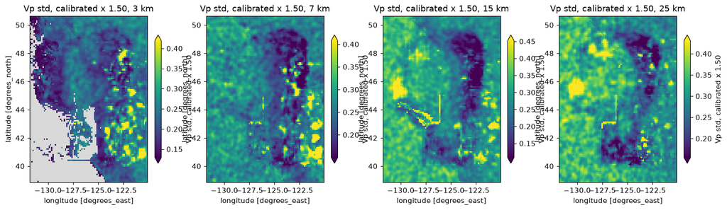

### Vs: ensemble standard deviation at depth (D-B094 calibrated: raw member std x 1.35) (grey: water, air or no value)

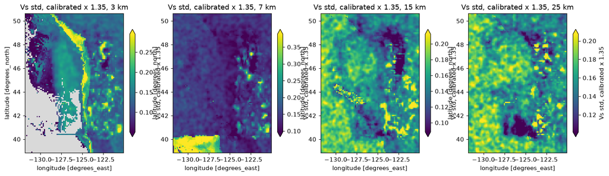

### VpVs: ensemble standard deviation at depth (not inflated) (grey: water, air or no value)

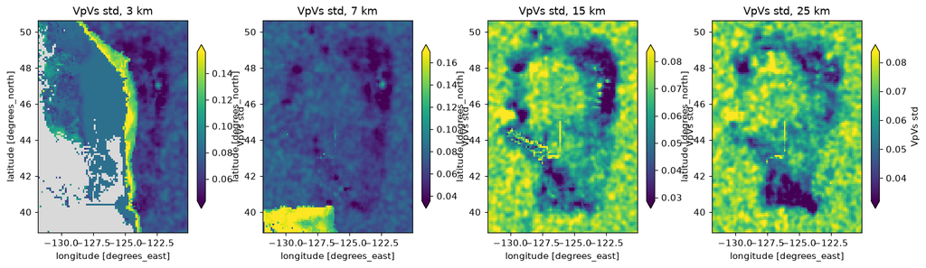

### Sections of the standard deviation, E-W at 44.5 N (calibrated, D-B094)

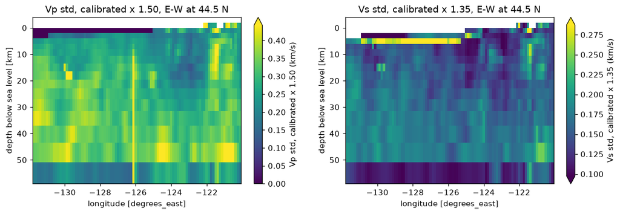

### Sections of the standard deviation, E-W at 47.5 N (calibrated, D-B094)

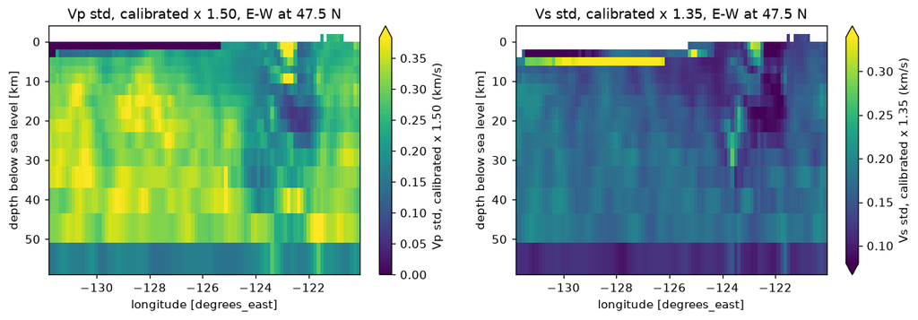

### Sections of the standard deviation, N-S at 125.0 W (calibrated, D-B094)

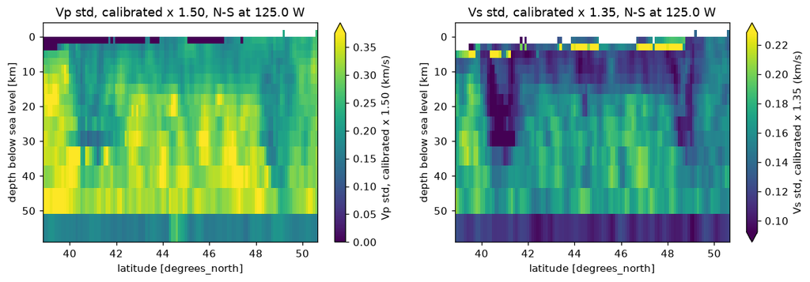